# Аналитическое резюме: аномалии налогового риска

Синтетический датасет · 500 компаний · 2023–2025

11.07.2026

## Что нашли

Из **500** компаний выявлено **14** приоритетных (высокий риск × высокая материальность), **81** фоновых и **54** случаев, которые являются реальными экономическими сигналами, а не аномалиями. Анализ ведётся через призму **налогового риска**: восемь типологий, из которых четыре — ведущие (низкая эффективная ставка налога, «технические»/транзитные фирмы, вывод прибыли через дивиденды, аномалии маржи относительно отрасли).

## Как проверяли

Отклонения измеряются **относительно отрасли** (`okved_section`) робастной статистикой (медиана/MAD, порог |z| ≥ 3.5) с откатом на глобальную норму для малых отраслей. Арифметические невозможности (дивиденды > чистой прибыли, нарушение тождеств P&L) проверяются абсолютными правилами. Приоритет = **вероятность × материальность**.

## Приоритетная карта

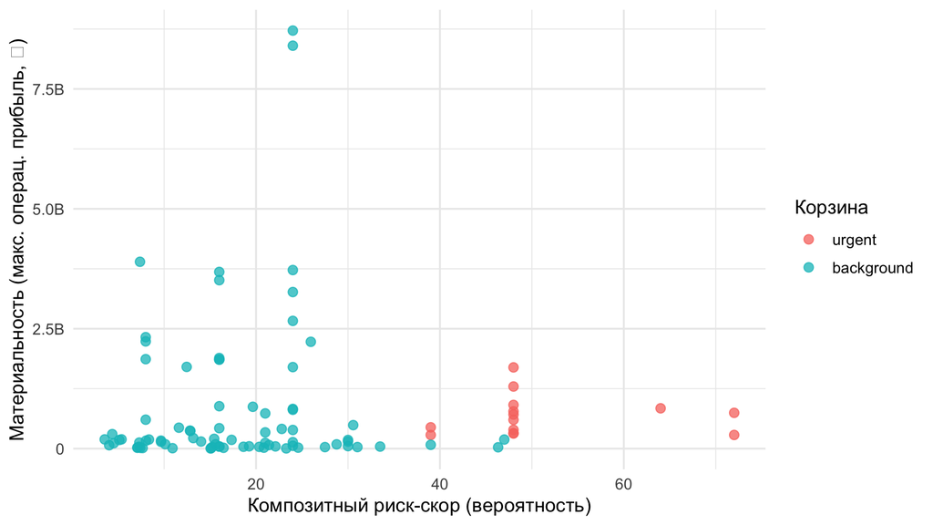

## Частота срабатывания типологий

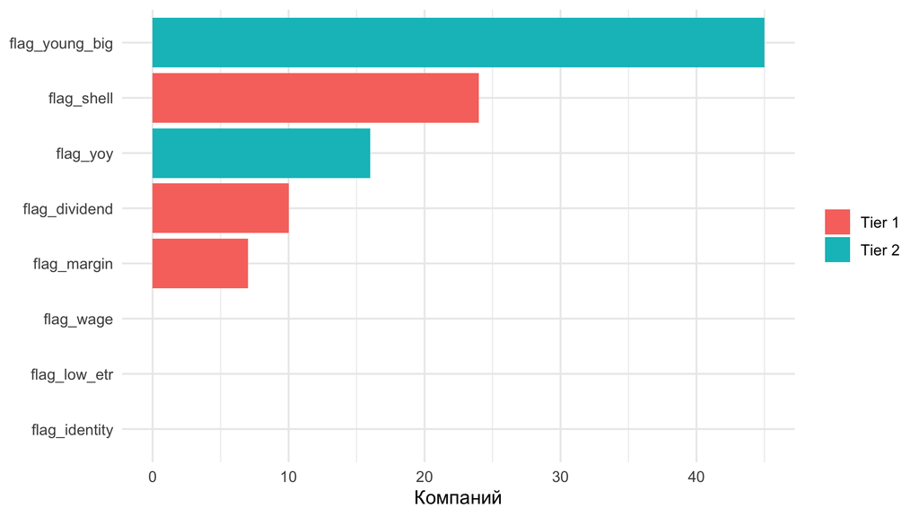